# Temas para Rmarkdown

Luis Andrés Rojas García Exp. 279465

septiembre 27 , 2022

# Tema preestablecido

Cuando usamos Rmarkdown y creamos el archivo .html, este tendrá un tema preestablecido.

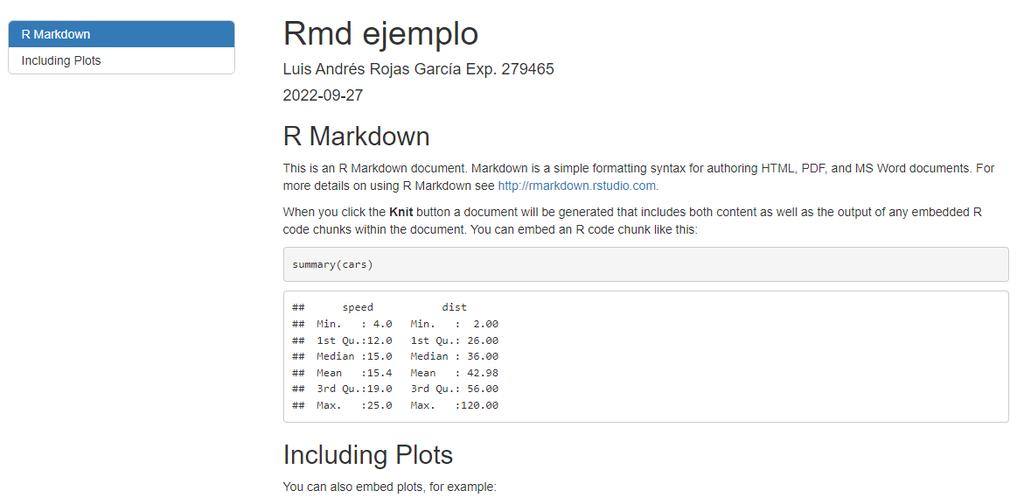

# Temas preliminares

Sin embargo, podemos ir cambiando la visualización del tema en el archivo .html.  
Esto lo podemos hacer al establecer el tema en el material preliminar YAML.

```
---
title: "Rmd ejemplo"
author: "Luis Andrés Rojas García Exp. 279465"
date: "2022-09-27"
output: html_document
---
```

En esta parte, debemos seleccionar el tema del paquete predeterminado que deseemos. Estos inclyen a:

## cerulean

```
---
title: "Rmd ejemplo"
author: "Luis Andrés Rojas García Exp. 279465"
date: "2022-09-27"
output:
  html_document:
    theme: cerulean
    toc: yes
    toc_float:
      collapsed: no
      smooth_scroll: yes
---
```

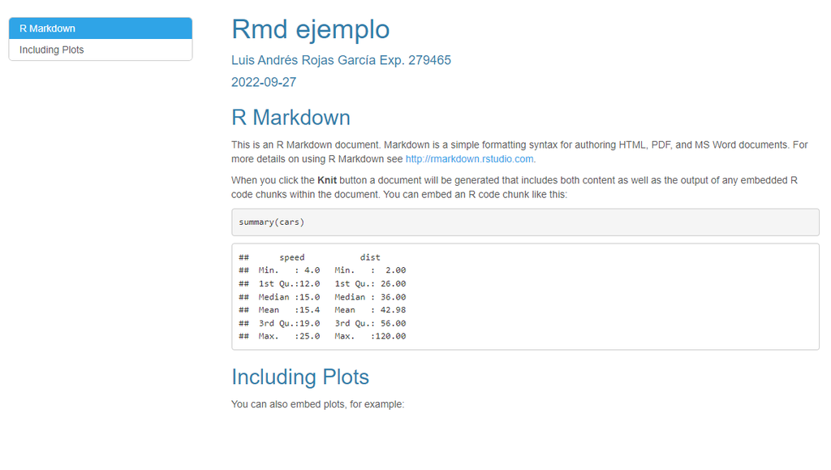

## cosmo

```
---
title: "Rmd ejemplo"
author: "Luis Andrés Rojas García Exp. 279465"
date: "2022-09-27"
output:
  html_document:
    theme: cosmo
    toc: yes
    toc_float:
      collapsed: no
      smooth_scroll: yes
---
```

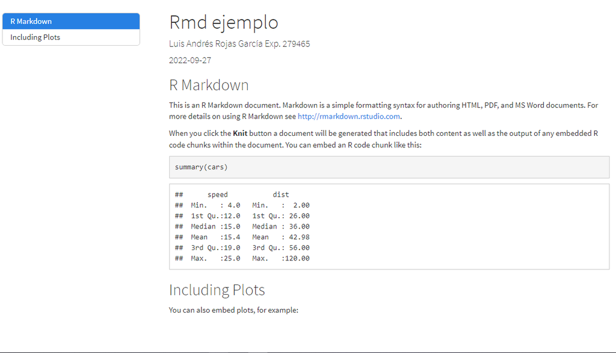

## flatly

```
---
title: "Rmd ejemplo"
author: "Luis Andrés Rojas García Exp. 279465"
date: "2022-09-27"
output:
  html_document:
    theme: flatly
    toc: yes
    toc_float:
      collapsed: no
      smooth_scroll: yes
---
```

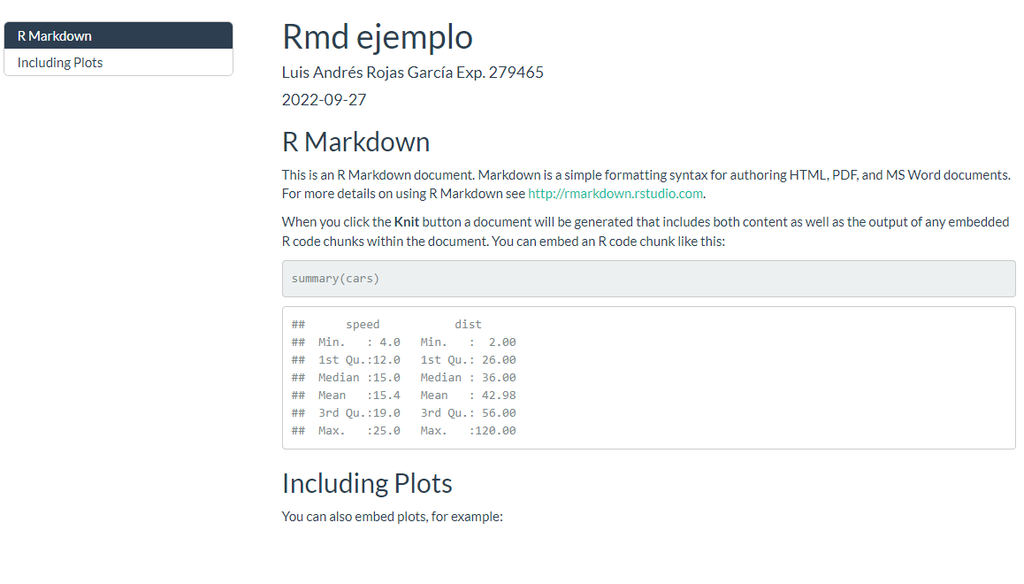

## journal

```
---
title: "Rmd ejemplo"
author: "Luis Andrés Rojas García Exp. 279465"
date: "2022-09-27"
output:
  html_document:
    theme: journal
    toc: yes
    toc_float:
      collapsed: no
      smooth_scroll: yes
---
```

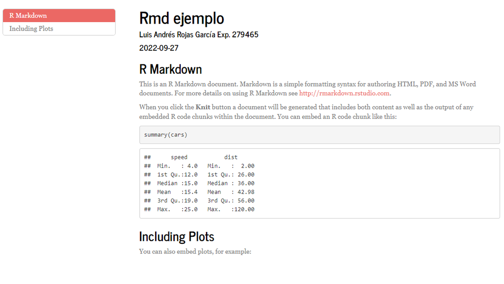

## lumen

```
---
title: "Rmd ejemplo"
author: "Luis Andrés Rojas García Exp. 279465"
date: "2022-09-27"
output:
  html_document:
    theme: lumen
    toc: yes
    toc_float:
      collapsed: no
      smooth_scroll: yes
---
```

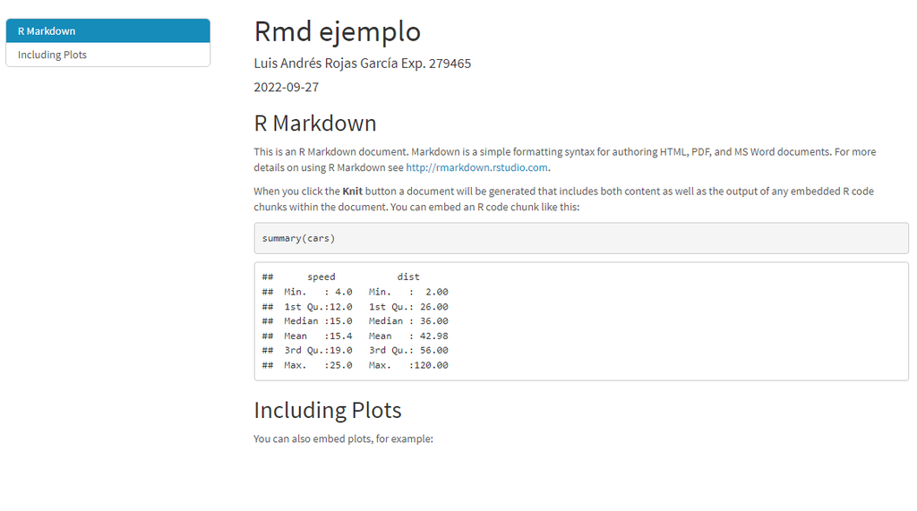

## paper

```
---
title: "Rmd ejemplo"
author: "Luis Andrés Rojas García Exp. 279465"
date: "2022-09-27"
output:
  html_document:
    theme: paper
    toc: yes
    toc_float:
      collapsed: no
      smooth_scroll: yes
---
```

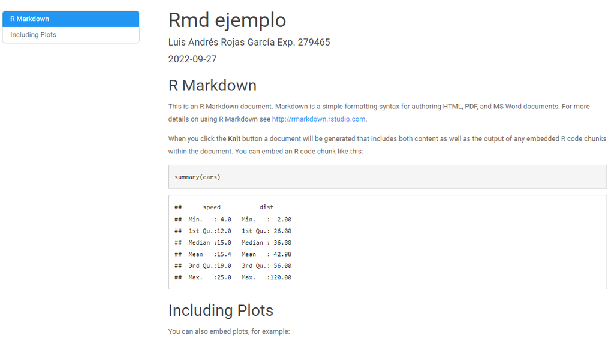

## readable

```
---
title: "Rmd ejemplo"
author: "Luis Andrés Rojas García Exp. 279465"
date: "2022-09-27"
output:
  html_document:
    theme: readable
    toc: yes
    toc_float:
      collapsed: no
      smooth_scroll: yes
---
```

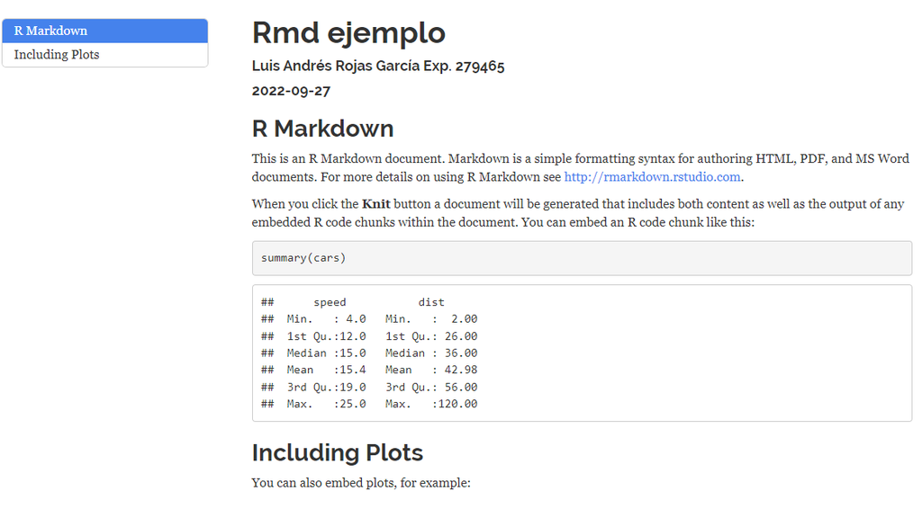

## sandstone

```
---
title: "Rmd ejemplo"
author: "Luis Andrés Rojas García Exp. 279465"
date: "2022-09-27"
output:
  html_document:
    theme: sandstone
    toc: yes
    toc_float:
      collapsed: no
      smooth_scroll: yes
---
```

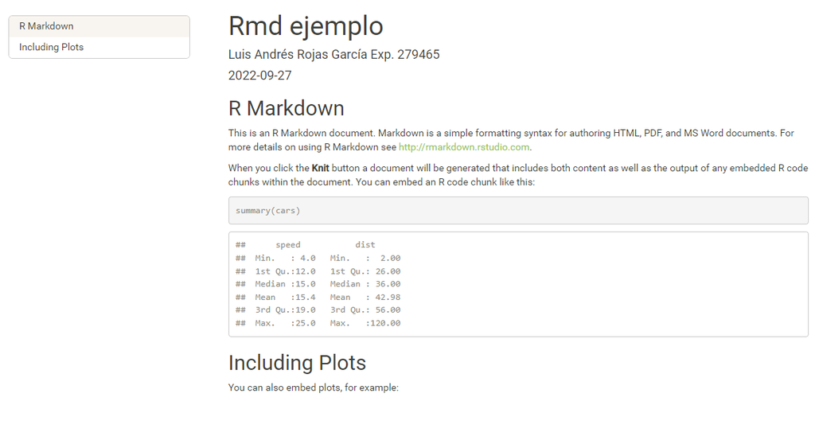

## simplex

```
---
title: "Rmd ejemplo"
author: "Luis Andrés Rojas García Exp. 279465"
date: "2022-09-27"
output:
  html_document:
    theme: simplex
    toc: yes
    toc_float:
      collapsed: no
      smooth_scroll: yes
---
```

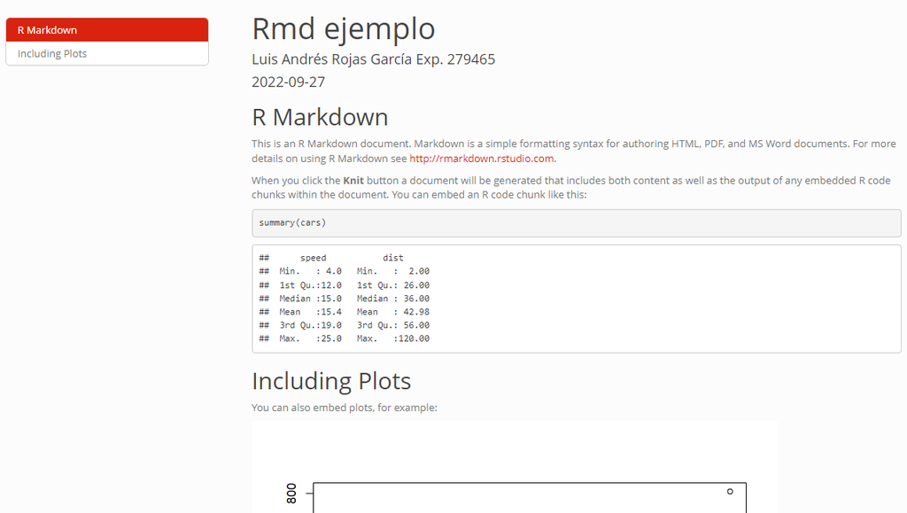

## spacelab

```
---
title: "Rmd ejemplo"
author: "Luis Andrés Rojas García Exp. 279465"
date: "2022-09-27"
output:
  html_document:
    theme: spacelab
    toc: yes
    toc_float:
      collapsed: no
      smooth_scroll: yes
---
```

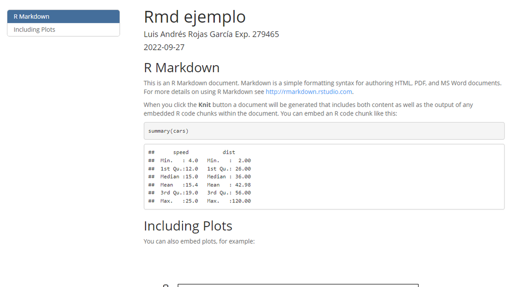

## united

```
---
title: "Rmd ejemplo"
author: "Luis Andrés Rojas García Exp. 279465"
date: "2022-09-27"
output:
  html_document:
    theme: united
    toc: yes
    toc_float:
      collapsed: no
      smooth_scroll: yes
---
```

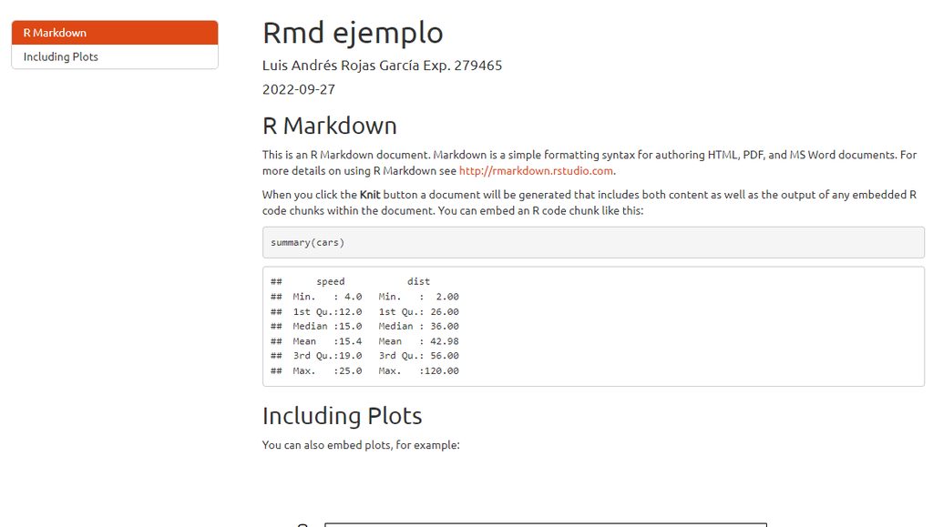

## yeti

```
---
title: "Rmd ejemplo"
author: "Luis Andrés Rojas García Exp. 279465"
date: "2022-09-27"
output:
  html_document:
    theme: yeti
    toc: yes
    toc_float:
      collapsed: no
      smooth_scroll: yes
---
```

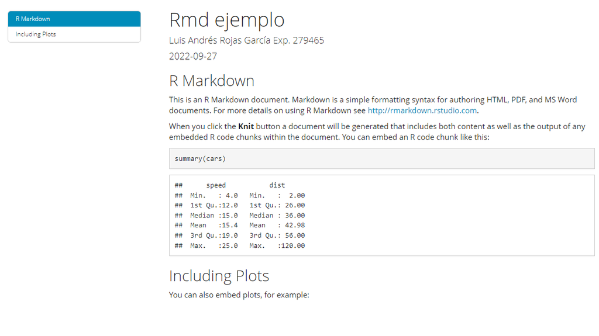

# Otros colores

Si quieres que tu Rmarkdown sea más personalizado, tenga más estilo o un mejor diseño, puedes aplicar otros temas que vienen incluidos en algunos paquetes. Para ello, debes tener instalado el paquete del cual quieres aplicar el tema.

## ipsum

El paquete para este tema es *hrbrthemes*

```
install.packages("hrbrthemes")
```

```
---
title: "Rmd ejemplo"
author: "Luis Andrés Rojas García Exp. 279465"
date: "2022-09-27"
output:
  hrbrthemes::ipsum:
    toc: yes
    toc_float:
      collapsed: no
      smooth_scroll: yes
---
```

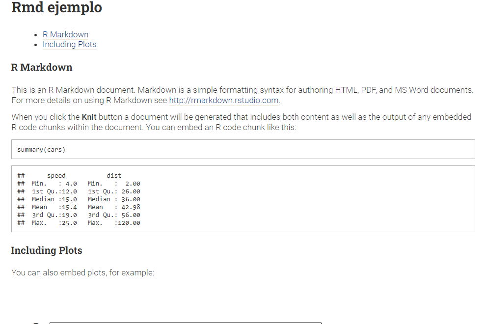

## architect

El paquete para este tema es *prettydoc*

```
install.packages("prettydoc")
```

```
---
title: "Rmd ejemplo"
author: "Luis Andrés Rojas García Exp. 279465"
date: "2022-09-27"
output:
  prettydoc::html_pretty:
    theme: architect
    toc: yes
---
```

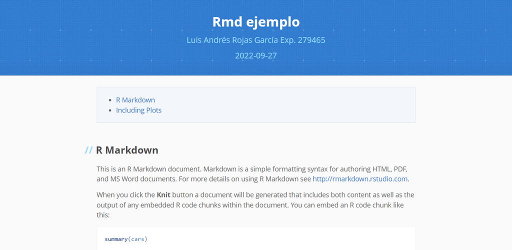

## cayman

El paquete para este tema es *prettydoc*

```
install.packages("prettydoc")
```

```
---
title: "Rmd ejemplo"
author: "Luis Andrés Rojas García Exp. 279465"
date: "2022-09-27"
output:
  prettydoc::html_pretty:
    theme: cayman
    toc: yes
---
```

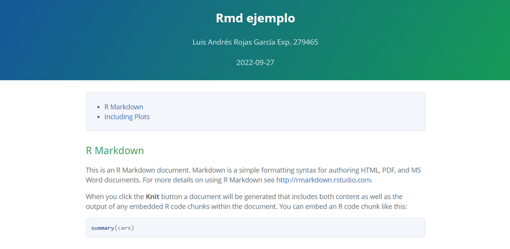

## hpstr

El paquete para este tema es *prettydoc*

```
install.packages("prettydoc")
```

```
---
title: "Rmd ejemplo"
author: "Luis Andrés Rojas García Exp. 279465"
date: "2022-09-27"
output:
  prettydoc::html_pretty:
    theme: hpstr
    toc: yes
---
```

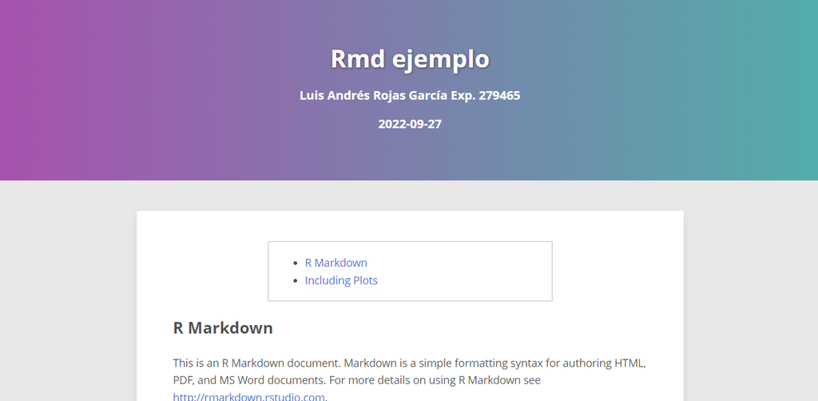

## leonids

El paquete para este tema es *prettydoc*

```
install.packages("prettydoc")
```

```
---
title: "Rmd ejemplo"
author: "Luis Andrés Rojas García Exp. 279465"
date: "2022-09-27"
output:
  prettydoc::html_pretty:
    theme: leonids
    toc: yes
---
```

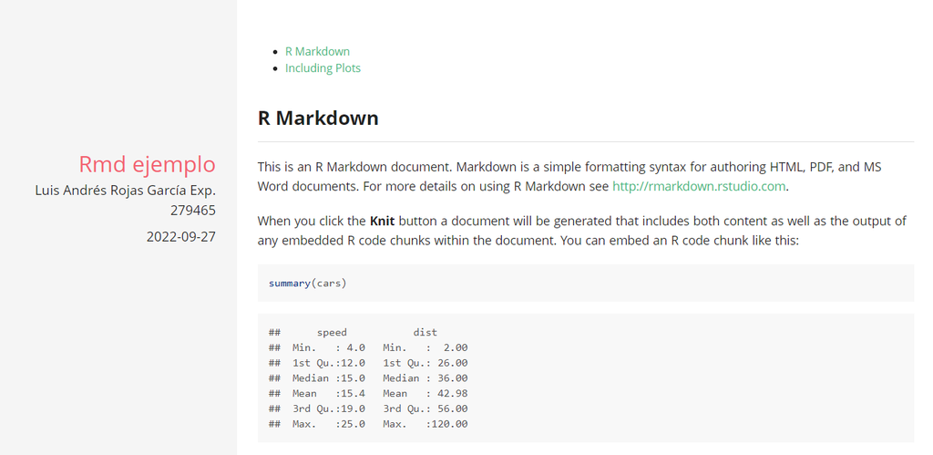

## tactile

El paquete para este tema es *prettydoc*

```
install.packages("prettydoc")
```

```
---
title: "Rmd ejemplo"
author: "Luis Andrés Rojas García Exp. 279465"
date: "2022-09-27"
output:
  prettydoc::html_pretty:
    theme: tactile
    toc: yes
---
```

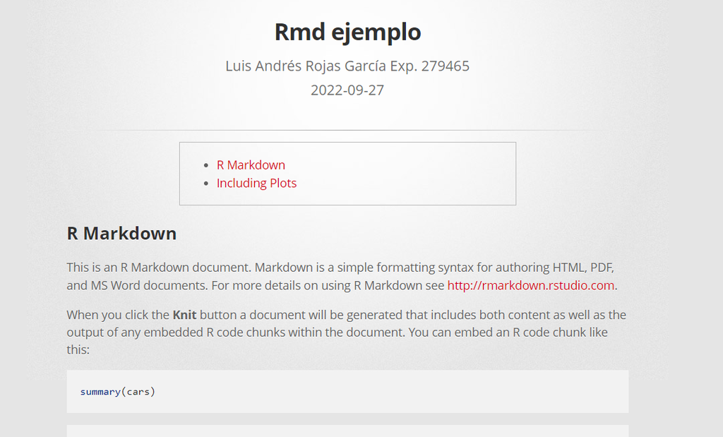

## html_clean

El paquete para este tema es *rmdformats*

```
install.packages("rmdformats")
```

```
---
title: "Rmd ejemplo"
author: "Luis Andrés Rojas García Exp. 279465"
date: "2022-09-27"
output: rmdformats::html_clean
---
```

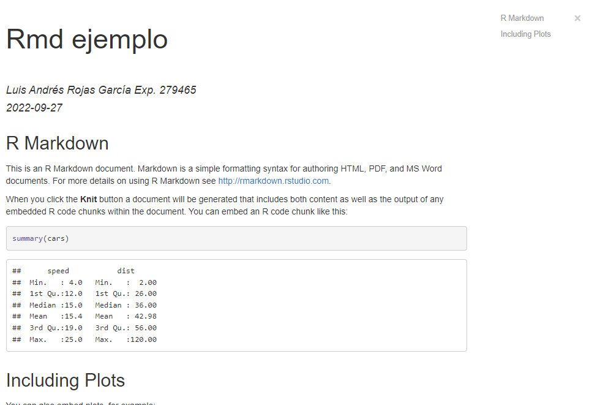

## html_docco

El paquete para este tema es *rmdformats*

```
install.packages("rmdformats")
```

```
---
title: "Rmd ejemplo"
author: "Luis Andrés Rojas García Exp. 279465"
date: "2022-09-27"
output: rmdformats::html_docco
---
```

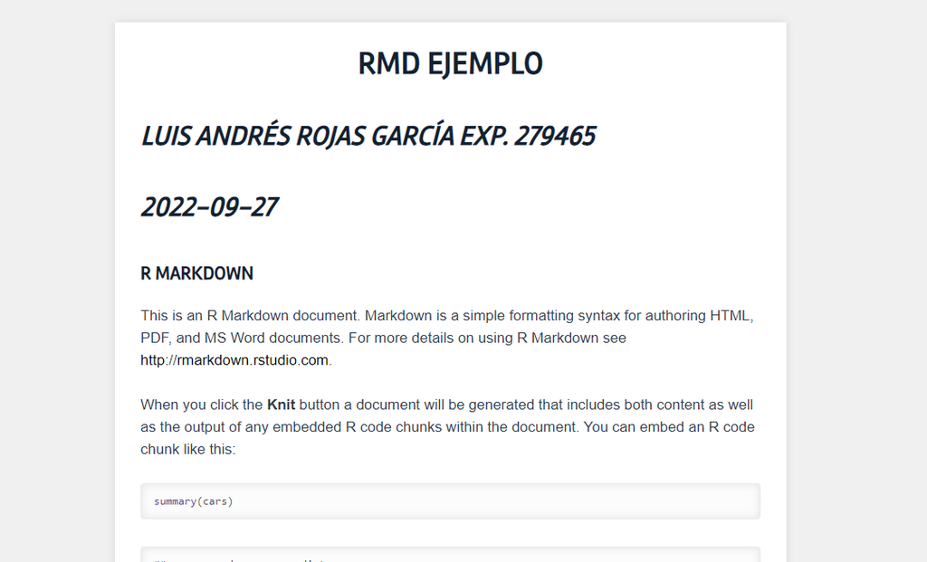

## readthedown

El paquete para este tema es *rmdformats*

```
install.packages("rmdformats")
```

```
---
title: "Rmd ejemplo"
author: "Luis Andrés Rojas García Exp. 279465"
date: "2022-09-27"
output: rmdformats::readthedown
---
```

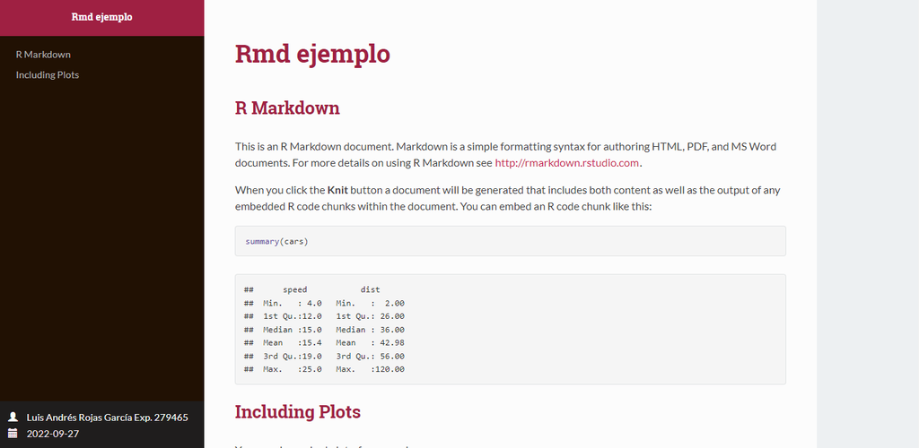

## material

El paquete para este tema es *rmdformats*

```
install.packages("rmdformats")
```

```
---
title: "Rmd ejemplo"
author: "Luis Andrés Rojas García Exp. 279465"
date: "2022-09-27"
output: rmdformats::material
---
```

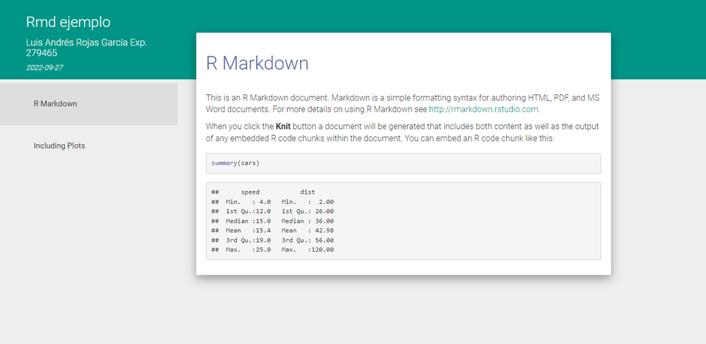

## robobook

El paquete para este tema es *rmdformats*

```
install.packages("rmdformats")
```

```
---
title: "Rmd ejemplo"
author: "Luis Andrés Rojas García Exp. 279465"
date: "2022-09-27"
output: rmdformats::robobook
---
```

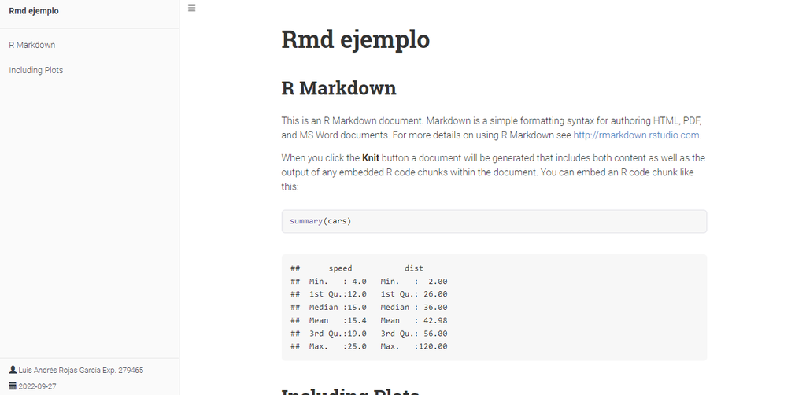

## downcute

El paquete para este tema es *rmdformats*

```
install.packages("rmdformats")
```

```
---
title: "Rmd ejemplo"
author: "Luis Andrés Rojas García Exp. 279465"
date: "2022-09-27"
output: rmdformats::downcute
---
```

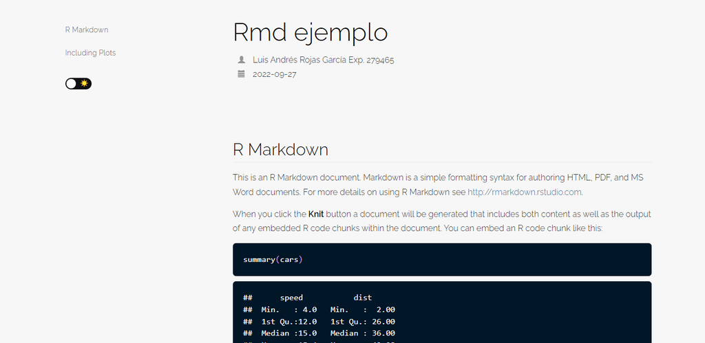

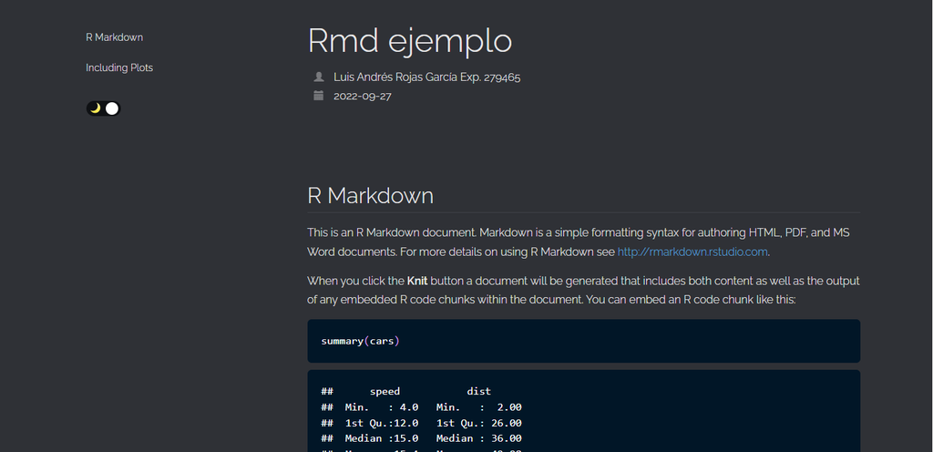

## tint

El paquete para este tema es *tint*

```
install.packages("tint")
```

```
---
title: "Rmd ejemplo"
author: "Luis Andrés Rojas García Exp. 279465"
date: "2022-09-27"
output: tint::tintHtml
---
```

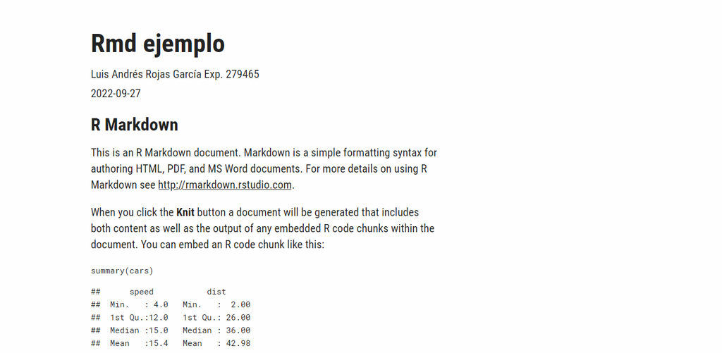

## tufte_html

El paquete para este tema es *tufte*

```
install.packages("tufte")
```

```
---
title: "Rmd ejemplo"
author: "Luis Andrés Rojas García Exp. 279465"
date: "2022-09-27"
output: tufte::tufte_html
---
```

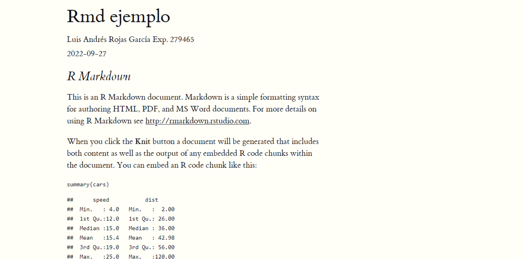